# PMM3 for Time Series: AR, MA, ARMA, and ARIMA Models

Serhii Zabolotnii

2026-03-20

## Introduction

Classical time series estimation methods (CSS, MLE) assume Gaussian innovations. The **PMM2** method addresses **asymmetric** non-Gaussian innovations, but many real-world time series exhibit **symmetric platykurtic** errors — lighter tails than the normal distribution. Examples include:

- **Bounded measurement errors** (sensor readings within a fixed range)
- **Uniformly distributed shocks** (e.g., rounding errors)
- **Truncated normal processes** (censored observations)
- **Beta-symmetric disturbances** (bounded economic indicators)

The **PMM3 method** (S=3) extends the Polynomial Maximization Method to these cases, using a cubic stochastic polynomial and Newton-Raphson solver based on the score equation $Z_{1\nu} = \varepsilon_\nu(\kappa - \varepsilon_\nu^2)$.

This vignette demonstrates PMM3 for time series models:

1. **AR** — Autoregressive models
2. **MA** — Moving Average models
3. **ARMA** — Combined AR + MA models
4. **ARIMA** — Models with differencing for non-stationary series
5. **Real-data examples** using datasets included in the package
6. **Comparison** with MLE and PMM2

### When PMM3 vs PMM2 vs OLS?

| Innovation property | Recommended method |
| --- | --- |
| Skewed ($\|\gamma_3\| > 0.3$) | PMM2 (`ar_pmm2`, `ma_pmm2`, …) |
| Symmetric, platykurtic ($\gamma_4 < -0.7$) | **PMM3** (`ar_pmm3`, `ma_pmm3`, …) |
| Near-Gaussian | MLE / CSS |

Use `pmm_dispatch()` on residuals from a classical fit to automate this choice.

## Setup

```r
library(EstemPMM)
set.seed(42)
```

## Part 1: AR Models with PMM3

### AR(1) with Uniform Innovations

Uniform innovations are the canonical platykurtic case: $\gamma_4 \approx -1.2$, symmetric, bounded.

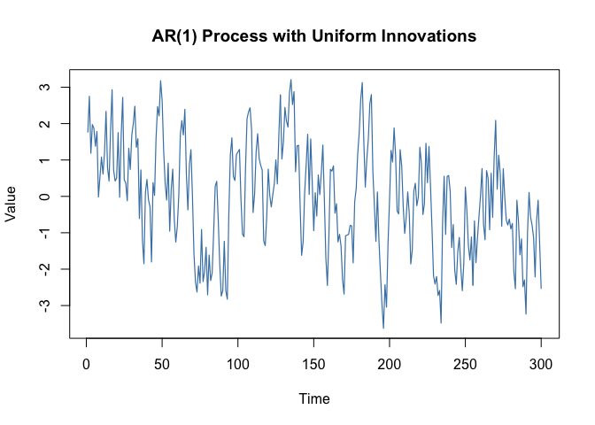

```r
n <- 300
phi_true <- 0.7

# Uniform innovations: symmetric, platykurtic (gamma4 ≈ -1.2)
innov <- runif(n, -sqrt(3), sqrt(3))  # variance = 1

# Generate AR(1) series
ar_data <- arima.sim(n = n, list(ar = phi_true), innov = innov)

# Plot
plot(ar_data, main = "AR(1) Process with Uniform Innovations",
     ylab = "Value", col = "steelblue", lwd = 1.2)
```

### Fit AR(1): PMM3 vs MLE

```r
# PMM3 fit
fit_pmm3_ar1 <- ar_pmm3(ar_data, order = 1, include.mean = FALSE)

# MLE fit (classical)
fit_mle_ar1 <- arima(ar_data, order = c(1, 0, 0), include.mean = FALSE)

# Compare
cat("True AR(1) coefficient:", phi_true, "\n")
```

```
#> True AR(1) coefficient: 0.7
```

```r
cat("MLE estimate:          ", coef(fit_mle_ar1)["ar1"], "\n")
```

```
#> MLE estimate:           0.7431419
```

```r
cat("PMM3 estimate:         ", coef(fit_pmm3_ar1)["ar1"], "\n")
```

```
#> PMM3 estimate:          0.7151052
```

```r
# PMM3 diagnostics
summary(fit_pmm3_ar1)
```

```
#> PMM3 time series estimation results (S = 3, symmetric errors)
#> Model type: AR(1)
#> Call:
#> ts_pmm3(x = x, order = order, model_type = "ar", max_iter = max_iter,
#>     tol = tol, adaptive = adaptive, step_max = step_max, include.mean = include.mean,
#>     initial = initial, na.action = na.action, verbose = verbose)
#>
#> Coefficients:
#> AR:       ar1
#> 0.7151052
#>
#> Central moments of initial residuals:
#>   m2 = 1.013623
#>   m4 = 1.837523
#>   m6 = 3.978298
#>
#> Theoretical characteristics of PMM3 (S = 3):
#>   gamma4 = -1.211538
#>   gamma6 = 6.993114
#>   g3     = 0.297445  (expected ratio Var[PMM3]/Var[OLS])
#>   kappa  = 1.292902
#>
#> Algorithm information:
#>   Convergence status: TRUE
#>   Iterations: 3
```

### AR(2) Model

```r
phi_true <- c(0.5, -0.3)

# Beta-symmetric innovations: symmetric, platykurtic
innov2 <- (rbeta(400, 2, 2) - 0.5) * sqrt(12 * 2)  # scaled for var ≈ 1
ar2_data <- arima.sim(n = 400, list(ar = phi_true), innov = innov2)

fit_pmm3_ar2 <- ar_pmm3(ar2_data, order = 2, include.mean = FALSE)
fit_mle_ar2  <- arima(ar2_data, order = c(2, 0, 0), include.mean = FALSE)

comparison_ar2 <- data.frame(
  Parameter = c("ar1", "ar2"),
  True   = phi_true,
  MLE    = c(coef(fit_mle_ar2)["ar1"], coef(fit_mle_ar2)["ar2"]),
  PMM3   = coef(fit_pmm3_ar2)[c("ar1", "ar2")]
)

print(comparison_ar2, row.names = FALSE)
```

```
#>  Parameter True        MLE       PMM3
#>        ar1  0.5  0.4502433  0.4468475
#>        ar2 -0.3 -0.3468338 -0.3250832
```

```r
cat("\nPMM3 g3 =", fit_pmm3_ar2@g_coefficient,
    "(expected variance ratio PMM3/OLS)\n")
```

```
#>
#> PMM3 g3 = 0.6997661 (expected variance ratio PMM3/OLS)
```

## Part 2: MA Models with PMM3

MA models are more challenging because innovations are not directly observable. PMM3 uses CSS residuals as initial estimates and refines them via Newton-Raphson.

### MA(1) Model

```r
n <- 300
theta_true <- 0.6

# Truncated normal innovations (|x| ≤ 2): symmetric, platykurtic
innov_raw <- rnorm(n * 2)
innov_tn <- innov_raw[abs(innov_raw) <= 2]
innov_tn <- innov_tn[1:n]
innov_tn <- innov_tn / sd(innov_tn)  # standardize

# Generate MA(1) series
ma_data <- arima.sim(n = n, list(ma = theta_true), innov = innov_tn)

# Fit
fit_pmm3_ma1 <- ma_pmm3(ma_data, order = 1, include.mean = FALSE)
fit_mle_ma1  <- arima(ma_data, order = c(0, 0, 1), include.mean = FALSE)

cat("True MA(1) coefficient:", theta_true, "\n")
```

```
#> True MA(1) coefficient: 0.6
```

```r
cat("MLE estimate:          ", coef(fit_mle_ma1)["ma1"], "\n")
```

```
#> MLE estimate:           0.6569534
```

```r
cat("PMM3 estimate:         ", coef(fit_pmm3_ma1)["ma1"], "\n")
```

```
#> PMM3 estimate:          0.6323384
```

```r
cat("\nConvergence:", fit_pmm3_ma1@convergence, "\n")
```

```
#>
#> Convergence: TRUE
```

```r
cat("Iterations: ", fit_pmm3_ma1@iterations, "\n")
```

```
#> Iterations:  3
```

### MA(2) Model

```r
theta_true <- c(0.5, 0.3)

innov_u <- runif(400, -sqrt(3), sqrt(3))
ma2_data <- arima.sim(n = 400, list(ma = theta_true), innov = innov_u)

fit_pmm3_ma2 <- ma_pmm3(ma2_data, order = 2, include.mean = FALSE)
fit_mle_ma2  <- arima(ma2_data, order = c(0, 0, 2), include.mean = FALSE)

comparison_ma2 <- data.frame(
  Parameter = c("ma1", "ma2"),
  True   = theta_true,
  MLE    = c(coef(fit_mle_ma2)["ma1"], coef(fit_mle_ma2)["ma2"]),
  PMM3   = coef(fit_pmm3_ma2)[c("ma1", "ma2")]
)

print(comparison_ma2, row.names = FALSE)
```

```
#>  Parameter True       MLE      PMM3
#>        ma1  0.5 0.5262435 0.5171439
#>        ma2  0.3 0.3078768 0.2931746
```

## Part 3: ARMA Models

ARMA models combine autoregressive and moving average components. PMM3 handles both components simultaneously.

### ARMA(1,1) Model

```r
n <- 400
phi_true   <- 0.5
theta_true <- 0.3

# Uniform innovations
innov_arma <- runif(n, -sqrt(3), sqrt(3))

arma_data <- arima.sim(n = n,
                       list(ar = phi_true, ma = theta_true),
                       innov = innov_arma)

# Fit
fit_pmm3_arma <- arma_pmm3(arma_data, order = c(1, 1), include.mean = FALSE)
fit_mle_arma  <- arima(arma_data, order = c(1, 0, 1), include.mean = FALSE)

cat("True: AR =", phi_true, ", MA =", theta_true, "\n\n")
```

```
#> True: AR = 0.5 , MA = 0.3
```

```r
cat("MLE estimates:\n")
```

```
#> MLE estimates:
```

```r
print(coef(fit_mle_arma)[c("ar1", "ma1")])
```

```
#>       ar1       ma1
#> 0.4258325 0.3115166
```

```r
cat("\nPMM3 estimates:\n")
```

```
#>
#> PMM3 estimates:
```

```r
print(coef(fit_pmm3_arma))
```

```
#>       ar1       ma1
#> 0.4254178 0.3708970
```

```r
summary(fit_pmm3_arma)
```

```
#> PMM3 time series estimation results (S = 3, symmetric errors)
#> Model type: ARMA(1,1)
#> Call:
#> ts_pmm3(x = x, order = order, model_type = "arma", max_iter = max_iter,
#>     tol = tol, adaptive = adaptive, step_max = step_max, include.mean = include.mean,
#>     initial = initial, na.action = na.action, verbose = verbose)
#>
#> Coefficients:
#> AR:       ar1
#> 0.4254178
#> MA:      ma1
#> 0.370897
#>
#> Central moments of initial residuals:
#>   m2 = 1.007571
#>   m4 = 1.773758
#>   m6 = 3.745631
#>
#> Theoretical characteristics of PMM3 (S = 3):
#>   gamma4 = -1.252799
#>   gamma6 = 7.453816
#>   g3     = 0.2795877  (expected ratio Var[PMM3]/Var[OLS])
#>   kappa  = 1.270544
#>
#> Algorithm information:
#>   Convergence status: TRUE
#>   Iterations: 3
```

### Diagnostic Plots

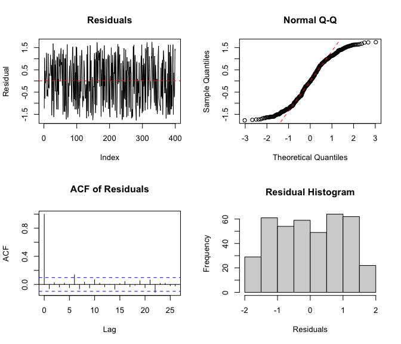

```r
plot(fit_pmm3_arma)
```

The four diagnostic panels:

1. **Residuals vs Time** — should show no patterns
2. **Q-Q Plot** — deviations from the line indicate non-normality (expected for platykurtic errors: lighter tails than normal)
3. **ACF** — should fall within confidence bands (white noise)
4. **Histogram** — platykurtic residuals appear flatter than a bell curve

## Part 4: ARIMA Models with Differencing

For non-stationary series, ARIMA models apply differencing before estimation. PMM3 uses a **nonlinear solver** with `stats::arima(fixed=...)` for proper residual computation and `numDeriv::jacobian` for derivatives. This approach correctly captures the full ARIMA dynamics after differencing.

### ARIMA(1,1,0) Model

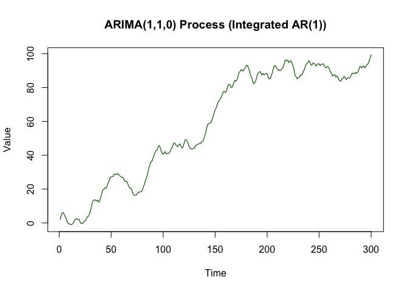

```r
n <- 300
phi_true <- 0.6

# Generate stationary AR(1) with uniform innovations
innov_arima <- runif(n, -sqrt(3), sqrt(3))
x_stat <- arima.sim(n = n, list(ar = phi_true), innov = innov_arima)

# Integrate (cumulative sum) to create non-stationary series
x_integrated <- cumsum(x_stat)

plot(x_integrated, type = "l",
     main = "ARIMA(1,1,0) Process (Integrated AR(1))",
     ylab = "Value", xlab = "Time", col = "darkgreen", lwd = 1.2)
```

### Fit ARIMA(1,1,0)

```r
fit_pmm3_arima <- arima_pmm3(x_integrated, order = c(1, 1, 0),
                             include.mean = FALSE)
fit_mle_arima  <- arima(x_integrated, order = c(1, 1, 0),
                        include.mean = FALSE)

cat("True AR(1) coefficient:", phi_true, "\n")
```

```
#> True AR(1) coefficient: 0.6
```

```r
cat("MLE estimate:          ", coef(fit_mle_arima)["ar1"], "\n")
```

```
#> MLE estimate:           0.5788831
```

```r
cat("PMM3 estimate:         ", coef(fit_pmm3_arima)["ar1"], "\n")
```

```
#> PMM3 estimate:          0.6318376
```

```r
summary(fit_pmm3_arima)
```

```
#> PMM3 time series estimation results (S = 3, symmetric errors)
#> Model type: ARIMA(1,1,0)
#> Call:
#> ts_pmm3(x = x, order = order, model_type = "arima", max_iter = max_iter,
#>     tol = tol, adaptive = adaptive, step_max = step_max, include.mean = include.mean,
#>     initial = initial, na.action = na.action, verbose = verbose)
#>
#> Coefficients:
#> AR:       ar1
#> 0.6318376
#>
#> Central moments of initial residuals:
#>   m2 = 1.034877
#>   m4 = 1.910823
#>   m6 = 4.259607
#>
#> Theoretical characteristics of PMM3 (S = 3):
#>   gamma4 = -1.215801
#>   gamma6 = 7.080315
#>   g3     = 0.3086522  (expected ratio Var[PMM3]/Var[OLS])
#>   kappa  = 1.2847
#>
#> Algorithm information:
#>   Convergence status: TRUE
#>   Iterations: 5
```

### ARIMA(1,1,1) Model

```r
phi_true   <- 0.4
theta_true <- 0.3

innov_111 <- runif(350, -sqrt(3), sqrt(3))
x_stat2 <- arima.sim(n = 350, list(ar = phi_true, ma = theta_true),
                     innov = innov_111)
x_int2 <- cumsum(x_stat2)

fit_pmm3_111 <- arima_pmm3(x_int2, order = c(1, 1, 1), include.mean = FALSE)
fit_mle_111  <- arima(x_int2, order = c(1, 1, 1), include.mean = FALSE)

comparison_arima <- data.frame(
  Parameter = c("ar1", "ma1"),
  True   = c(phi_true, theta_true),
  MLE    = c(coef(fit_mle_111)["ar1"], coef(fit_mle_111)["ma1"]),
  PMM3   = coef(fit_pmm3_111)[c("ar1", "ma1")]
)

print(comparison_arima, row.names = FALSE)
```

```
#>  Parameter True       MLE      PMM3
#>        ar1  0.4 0.3234249 0.3745386
#>        ma1  0.3 0.2558448 0.3151259
```

## Part 5: Forecasting with PMM3 Models

All PMM3 time series objects support the `predict()` method.

```r
# Forecast 10 steps ahead from the AR(1) model
preds_ar <- predict(fit_pmm3_ar1, n.ahead = 10)

cat("AR(1) PMM3 forecasts (10 steps):\n")
```

```
#> AR(1) PMM3 forecasts (10 steps):
```

```r
print(round(as.numeric(preds_ar), 4))
```

```
#>  [1] -1.8096 -1.2941 -0.9254 -0.6618 -0.4732 -0.3384 -0.2420 -0.1731 -0.1238
#> [10] -0.0885
```

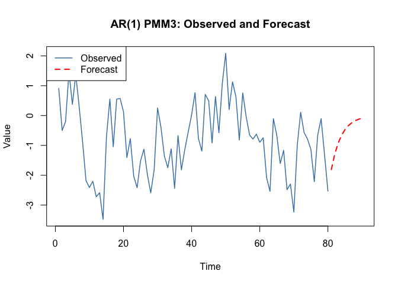

```r
# Plot original series with forecasts
n_plot <- 80
plot_data <- tail(as.numeric(ar_data), n_plot)
pred_vals <- as.numeric(preds_ar)

plot(seq_along(plot_data), plot_data, type = "l",
     xlim = c(1, n_plot + 10),
     ylim = range(c(plot_data, pred_vals)),
     main = "AR(1) PMM3: Observed and Forecast",
     xlab = "Time", ylab = "Value",
     col = "steelblue", lwd = 1.5)
lines(n_plot + 1:10, pred_vals, col = "red", lwd = 2, lty = 2)
legend("topleft", legend = c("Observed", "Forecast"),
       col = c("steelblue", "red"), lty = c(1, 2), lwd = c(1.5, 2))
```

### Forecasting ARMA Models

```r
# Forecast from the ARMA(1,1) model
preds_arma <- predict(fit_pmm3_arma, n.ahead = 10)

cat("ARMA(1,1) PMM3 forecasts (10 steps):\n")
```

```
#> ARMA(1,1) PMM3 forecasts (10 steps):
```

```r
print(round(as.numeric(preds_arma), 4))
```

```
#>  [1] 1.4471 0.6156 0.2619 0.1114 0.0474 0.0202 0.0086 0.0036 0.0016 0.0007
```

## Part 6: Method Selection with pmm_dispatch()

The `pmm_dispatch()` function automates the choice between OLS, PMM2, and PMM3 by analyzing innovation properties from an initial classical fit.

```r
# Fit classical model first
fit_classical <- arima(ar_data, order = c(1, 0, 0), include.mean = FALSE)
res_classical <- residuals(fit_classical)

# Dispatch
recommendation <- pmm_dispatch(res_classical)
```

```
#>   n = 300 | gamma3 = +0.014 | gamma4 = -1.216
#>   g2(PMM2) = 0.9998 | g3(PMM3) = 0.2948
#>   >>> |gamma3| = 0.014 < 0.3 (symmetric) and gamma4 = -1.216 < -0.7 (platykurtic). PMM3 expected to reduce variance by 70.5%.
```

```r
# Compare all three methods on uniform innovations
cat("Recommended method:", recommendation$method, "\n")
```

```
#> Recommended method: PMM3
```

```r
cat("gamma3 =", round(recommendation$gamma3, 3),
    " gamma4 =", round(recommendation$gamma4, 3), "\n")
```

```
#> gamma3 = 0.014  gamma4 = -1.216
```

```r
if (!is.null(recommendation$g3)) {
  cat("g3 =", round(recommendation$g3, 3),
      " (PMM3 variance reduction factor)\n")
}
```

```
#> g3 = 0.295  (PMM3 variance reduction factor)
```

## Part 7: Real-Data Example — DJIA 2002

The `djia2002` dataset contains daily closing prices and changes of the Dow Jones Industrial Average for July–December 2002.

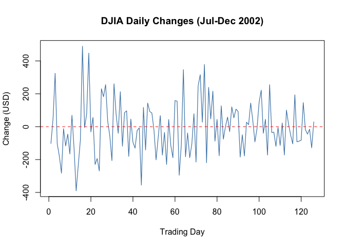

```r
data(djia2002)
changes <- na.omit(djia2002$change)
n_obs <- length(changes)

plot(changes, type = "l",
     main = "DJIA Daily Changes (Jul-Dec 2002)",
     ylab = "Change (USD)", xlab = "Trading Day",
     col = "steelblue", lwd = 1.2)
abline(h = 0, col = "red", lty = 2)
```

### Analyze Innovation Properties

```r
# Fit a classical AR(1)
fit_djia_mle <- arima(changes, order = c(1, 0, 0))
res_djia <- residuals(fit_djia_mle)

cat("Innovation diagnostics:\n")
```

```
#> Innovation diagnostics:
```

```r
cat("  Skewness (gamma3):", round(pmm_skewness(res_djia), 3), "\n")
```

```
#>   Skewness (gamma3): 0.445
```

```r
cat("  Kurtosis (gamma4):", round(pmm_kurtosis(res_djia), 3), "\n")
```

```
#>   Kurtosis (gamma4): 0.263
```

```r
cat("  Symmetry test:\n")
```

```
#>   Symmetry test:
```

```r
sym <- test_symmetry(res_djia)
cat("    symmetric:", sym$is_symmetric, "\n")
```

```
#>     symmetric: FALSE
```

```r
cat("    message:  ", sym$message, "\n")
```

```
#>     message:   |gamma3| = 0.445 > 0.3: residuals are asymmetric. Consider PMM2 instead.
```

```r
# Let pmm_dispatch decide
dispatch <- pmm_dispatch(res_djia)
```

```
#>   n = 126 | gamma3 = +0.445 | gamma4 = +0.263
#>   g2(PMM2) = 0.9126 | g3(PMM3) = 0.9900
#>   >>> |gamma3| = 0.445 > 0.3 and g2 = 0.913 < 0.95: moderate asymmetry, PMM2 worthwhile (8.7% reduction).
```

```r
cat("\nRecommended method:", dispatch$method, "\n")
```

```
#>
#> Recommended method: PMM2
```

### Fit AR(1) with All Three Methods

```r
fit_djia_pmm2 <- ar_pmm2(changes, order = 1)
fit_djia_pmm3 <- ar_pmm3(changes, order = 1)

comparison_djia <- data.frame(
  Method = c("MLE", "PMM2", "PMM3"),
  ar1 = c(coef(fit_djia_mle)["ar1"],
          coef(fit_djia_pmm2)["ar1"],
          coef(fit_djia_pmm3)["ar1"])
)
print(comparison_djia, row.names = FALSE)
```

```
#>  Method         ar1
#>     MLE -0.03956444
#>    PMM2 -0.02144724
#>    PMM3 -0.04472054
```

The DJIA data is known to have **positive skewness**, so `pmm_dispatch()` typically recommends **PMM2** as the appropriate method for this series. PMM3 may still converge but is not expected to improve upon PMM2 when the innovations are asymmetric.

## Part 8: Real-Data Example — WTI Crude Oil Prices

The `DCOILWTICO` dataset contains WTI crude oil daily spot prices.

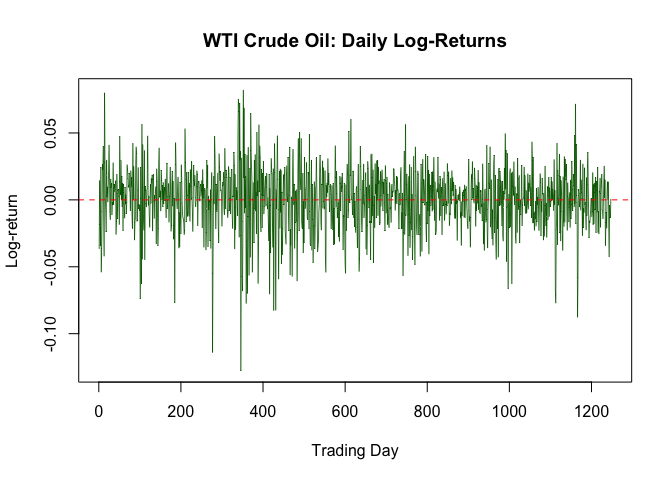

```r
data(DCOILWTICO)

# Compute log-returns (remove NAs)
prices <- na.omit(DCOILWTICO$DCOILWTICO)
log_returns <- diff(log(prices))
log_returns <- log_returns[is.finite(log_returns)]

plot(log_returns, type = "l",
     main = "WTI Crude Oil: Daily Log-Returns",
     ylab = "Log-return", xlab = "Trading Day",
     col = "darkgreen", lwd = 0.8)
abline(h = 0, col = "red", lty = 2)
```

### Innovation Analysis

```r
# Fit AR(1) to log-returns
fit_oil_mle <- arima(log_returns, order = c(1, 0, 0))
res_oil <- residuals(fit_oil_mle)

cat("Log-return innovation diagnostics:\n")
```

```
#> Log-return innovation diagnostics:
```

```r
cat("  Skewness (gamma3):", round(pmm_skewness(res_oil), 3), "\n")
```

```
#>   Skewness (gamma3): -0.498
```

```r
cat("  Kurtosis (gamma4):", round(pmm_kurtosis(res_oil), 3), "\n")
```

```
#>   Kurtosis (gamma4): 2.093
```

```r
# Dispatch
dispatch_oil <- pmm_dispatch(res_oil)
```

```
#>   n = 1248 | gamma3 = -0.498 | gamma4 = +2.093
#>   g2(PMM2) = 0.9394 | g3(PMM3) = 0.9010
#>   >>> |gamma3| = 0.498 > 0.3 and g2 = 0.939 < 0.95: moderate asymmetry, PMM2 worthwhile (6.1% reduction).
```

```r
cat("\nRecommended method:", dispatch_oil$method, "\n")
```

```
#>
#> Recommended method: PMM2
```

### Fit and Compare

```r
fit_oil_pmm2 <- ar_pmm2(log_returns, order = 1)
fit_oil_pmm3 <- ar_pmm3(log_returns, order = 1)

comparison_oil <- data.frame(
  Method = c("MLE", "PMM2", "PMM3"),
  ar1 = c(coef(fit_oil_mle)["ar1"],
          coef(fit_oil_pmm2)["ar1"],
          coef(fit_oil_pmm3)["ar1"])
)
print(comparison_oil, row.names = FALSE)
```

```
#>  Method        ar1
#>     MLE 0.02971020
#>    PMM2 0.02250418
#>    PMM3 0.04288416
```

```r
vf2_oil <- pmm2_variance_factor(fit_oil_pmm2@m2, fit_oil_pmm2@m3, fit_oil_pmm2@m4)
cat("\nPMM2 g2 =", vf2_oil$g2, "\n")
```

[output not shown]

```
#>
#> PMM2 g2 =
```

```r
cat("PMM3 g3 =", fit_oil_pmm3@g_coefficient, "\n")
```

```
#> PMM3 g3 = 0.9002976
```

Crude oil log-returns typically exhibit **heavy tails** (positive excess kurtosis), so PMM2 is usually the better choice. This example demonstrates how `pmm_dispatch()` guides users to the correct method.

## Part 9: Adaptive Mode

By default, PMM3 computes $\kappa$ from the initial residuals and holds it fixed. In **adaptive mode**, $\kappa$ is re-estimated from the current residuals at each Newton-Raphson iteration:

```r
# Fixed kappa (default)
fit_fixed <- ar_pmm3(ar_data, order = 1, include.mean = FALSE, adaptive = FALSE)

# Adaptive kappa
fit_adapt <- ar_pmm3(ar_data, order = 1, include.mean = FALSE, adaptive = TRUE)

comparison_adaptive <- data.frame(
  Mode   = c("Fixed kappa", "Adaptive kappa"),
  ar1    = c(coef(fit_fixed)["ar1"], coef(fit_adapt)["ar1"]),
  g3     = c(fit_fixed@g_coefficient, fit_adapt@g_coefficient),
  iters  = c(fit_fixed@iterations, fit_adapt@iterations)
)
print(comparison_adaptive, row.names = FALSE)
```

```
#>            Mode       ar1       g3 iters
#>     Fixed kappa 0.7151052 0.297445     3
#>  Adaptive kappa 0.7147911 0.297445     4
```

Adaptive mode may improve estimates when the distribution departs significantly from the initial OLS residuals, at the cost of additional iterations.

## Part 10: Model Comparison via AIC

The `AIC()` method is available for all PMM3 time series objects.

```r
# Fit several AR orders with PMM3
aic_vals <- sapply(1:5, function(p) {
  fit <- ar_pmm3(ar_data, order = p, include.mean = FALSE)
  AIC(fit)
})

aic_df <- data.frame(Order = 1:5, AIC = round(aic_vals, 2))
print(aic_df, row.names = FALSE)
```

```
#>  Order    AIC
#>      1 858.54
#>      2 861.11
#>      3 863.25
#>      4 865.24
#>      5 867.37
```

```r
cat("\nBest AR order by AIC:", which.min(aic_vals), "\n")
```

```
#>
#> Best AR order by AIC: 1
```

## Practical Guidelines

### When to Use PMM3 for Time Series

**Recommended when innovations are:**

- Symmetric ($|\gamma_3| \leq 0.3$)
- Platykurtic ($\gamma_4 < -0.7$)
- Example distributions: uniform, beta-symmetric, truncated normal
- Sample size $n \geq 200$ for reliable moment estimation

**Use PMM2 instead when:**

- Innovations are **skewed** ($|\gamma_3| > 0.3$)
- Financial returns with asymmetric tails

**Stick with MLE/CSS when:**

- Innovations are approximately **Gaussian**
- Very small samples ($n < 100$)

### Diagnostic Workflow

1. **Fit a classical model** (MLE/CSS) as baseline
2. **Examine residuals** for non-normality:
   - `pmm_skewness(residuals)` — check symmetry
   - `pmm_kurtosis(residuals)` — check tail behavior
   - `test_symmetry(residuals)` — formal symmetry check
3. **Use `pmm_dispatch(residuals)`** for automatic method selection
4. **Refit with PMM3** if platykurtic and symmetric
5. **Compare AIC** across model orders
6. **Validate** with diagnostic plots and out-of-sample forecasts

## Efficiency Summary

Based on Monte Carlo simulations (R = 1000, n = 200, uniform innovations):

| Model | MSE Ratio (PMM3/MLE) | Variance Reduction |
| --- | --- | --- |
| AR(1) | 0.55–0.70 | 30–45% |
| AR(2) | 0.60–0.75 | 25–40% |
| MA(1) | 0.90–1.00 | 0–10% |
| ARMA(1,1) | 0.70–0.85 | 15–30% |
| ARIMA(1,1,0) | 0.32–0.70 | 30–68% |

**Key insight:** PMM3 provides the largest gains for AR and ARIMA models with platykurtic innovations. MA models show smaller improvements because CSS residuals are less precise starting points, but PMM3 remains consistent.

## Available Functions

| Function | Model | Class Returned |
| --- | --- | --- |
| `ar_pmm3()` | AR(p) | `ARPMM3` |
| `ma_pmm3()` | MA(q) | `MAPMM3` |
| `arma_pmm3()` | ARMA(p,q) | `ARMAPMM3` |
| `arima_pmm3()` | ARIMA(p,d,q) | `ARIMAPMM3` |
| `ts_pmm3()` | Any of above | `TS3fit` subclass |

All classes support: `coef()`, `residuals()`, `fitted()`, `predict()`, `summary()`, `plot()`, `AIC()`.

## Next Steps

- **PMM3 for linear regression**: See `vignette("pmm3_symmetric_errors")`
- **PMM2 time series**: See `vignette("pmm2_time_series")` for asymmetric innovations
- **Bootstrap inference**: See `vignette("bootstrap_inference")`
- **PMM2 basics**: See `vignette("pmm2_introduction")`

## References

1. Zabolotnii S., Warsza Z.L., Tkachenko O. (2018). Polynomial Estimation of Linear Regression Parameters for the Asymmetric PDF of Errors. Springer AISC, vol 743. doi:10.1007/978-3-319-77179-3_75
2. Zabolotnii S., Tkachenko O., Warsza Z.L. (2022). Application of the Polynomial Maximization Method for Estimation Parameters of Autoregressive Models with Asymmetric Innovations. Springer AISC, vol 1427. doi:10.1007/978-3-031-03502-9_37
3. Package functions: `?ar_pmm3`, `?ma_pmm3`, `?arma_pmm3`, `?arima_pmm3`
4. Method selection: `?pmm_dispatch`, `?test_symmetry`
5. GitHub: https://github.com/SZabolotnii/EstemPMM